# Week 3 Homework

Author

Andrew Joyce

Published

January 21, 2023

```r
## setup et. al.
library(tidyverse)
```

## 3.1 Exercise

> *Complete the table.*

| Group ($T$) | $E[Y^1]$ | $E[Y^0]$ |
| --- | --- | --- |
| $T = 1$ | $10,000 | $5,000 |
| $T = 0$ | $10,000 | $5,000 |

> *Given that in the population, 30% are in T=1, calculate the ATE.*

## 3.2 Exercise

[output not shown]

## 3.3 Exercise

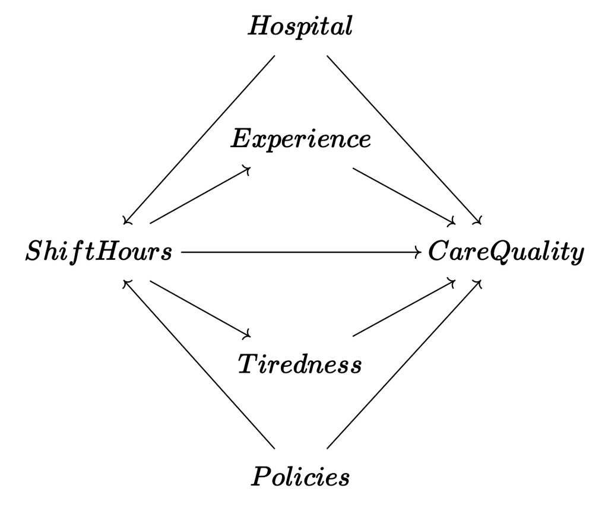

## 3.4 Exercise

> *Consider this RQ: Does the funding level of public schools affect student achievement for students in your country?*
1. **Treatment**: funding of public schools; **outcome**: student achievement
2. Relevant variables: parent SES, teacher-to-student ratio, intelligence, school district size
3. Which variables are causes of both treatment and outcome (ie., which variables are confounders)?  
   Parent SES is a confounder. In the US, funding for schools is based (in part) on property tax values, so parent SES contributes to school funding. However, parent SES can also impact student achievement- parents may be able to hire tutors, or per Lareau (2011), “cultivate” students for academic success.
4. Why might we want to pay extra attention to variables in Part C?  
   Since Parent SES is a confounding variable, it affects both the treatment and the outcome. There is a chance that the only reason the treatment and outcome are related is because of the confounder (if that is the case, we would say that the relationship between the treatment and outcome is *spurious*).
5. Draw a DAG

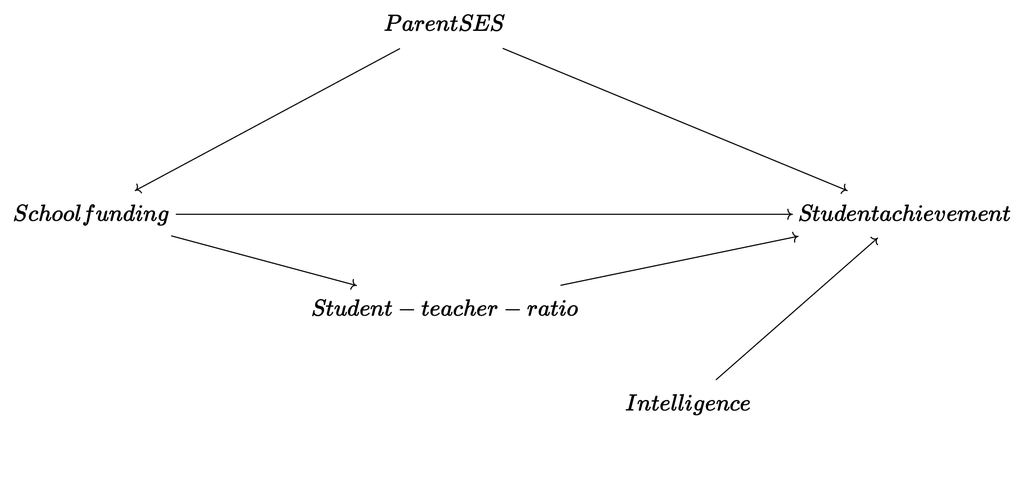

6. Simplify the diagram

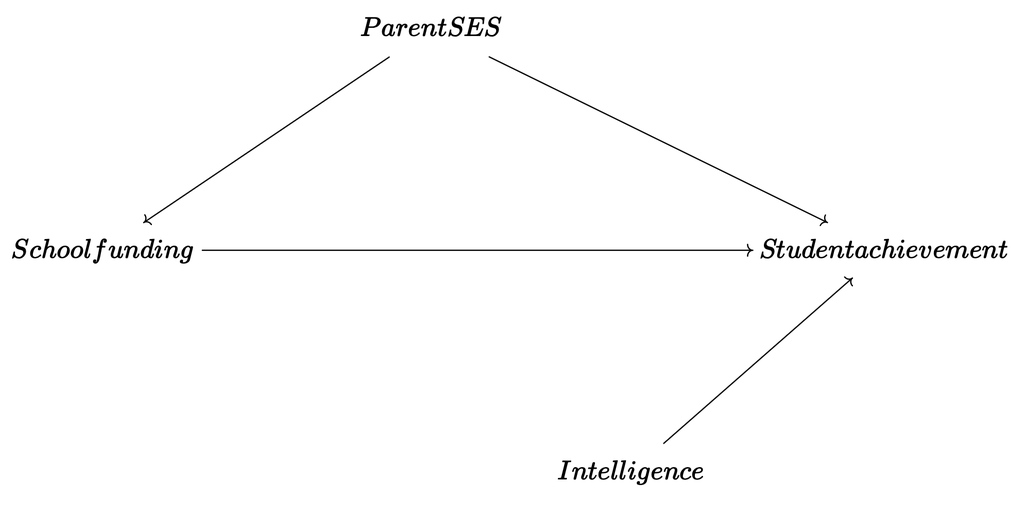

   Huntington-Klein (2022) says we can usually omit mediators to simplify a DAG. But this was a fairly simply DAG to begin with.

## 3.5 Exercise

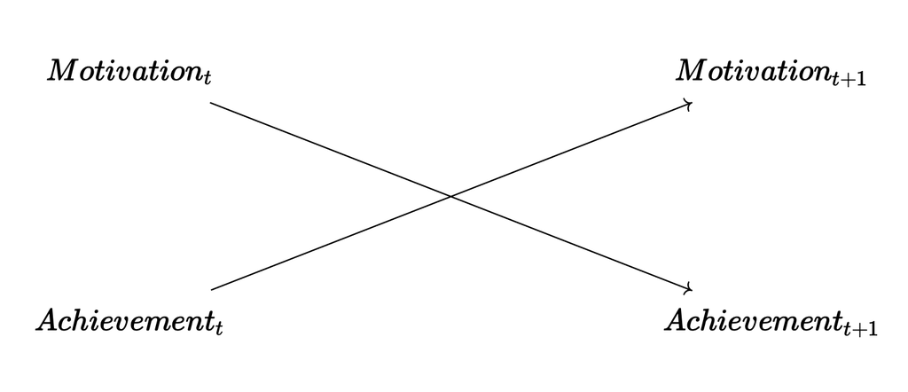

## 3.6 Exercise

> Assuming that a path has no colliders on it, what is the difference between a path being Open and Closed?

A path is closed if one of the variables has no variation. For example, say I have the following path:

$\text{Parent SES} \rightarrow \text{Educational Degree} \rightarrow \text{Earnings}$

Let’s say my sample has only individuals with a bachelor’s degree. There’s no variation in the variable for education- and therefore none of the relationship between Parent SES and earnings can be driven by education. Therefore the path is closed. But if my sample for those with an educational degree includes those with less than a high school diploma, a high school diploma, an associate’s degree, a bachelor’s degree, and an advanced degree, then I have variation in that variable and the path is opened.

## 3.7 Exercise

1. *List every path from X to Y.*  
   X $\rightarrow$ A $\rightarrow$ Y  
   X $\leftarrow$ B $\rightarrow$ Y  
   X $\leftarrow$ B $\leftarrow$ D $\rightarrow$ Y  
   X $\rightarrow$ C $\leftarrow$ D $\rightarrow$ Y  
   X $\rightarrow$ C $\leftarrow$ D $\rightarrow$ B $\rightarrow$ Y
2. *Which of the paths are front-door paths?*  
   X $\rightarrow$ A $\rightarrow$ Y
3. *Which of the paths are **open** back-door paths?*  
   X $\leftarrow$ B $\rightarrow$ Y.  
   X $\leftarrow$ B $\leftarrow$ D $\rightarrow$ Y  
   (C is a collider, so even though it appears in two other back-door paths, these are closed by default.)
4. *What variables must be controlled for in order to identify the effect of X on Y? (only list what must be controlled for, not anything that additionally could be controlled for).*  
   I would need to control for **B** and **D.**

## 3.8 Exercise

> *Which of the following describes a causal path where all the arrows point away from the treatment?*
1. Open Path
2. Closed Path
3. *Front Door Path*
4. Back Door Path

## 3.10 Exercise

> *Go to the app Steve showed us in class.*

> [*https://cbdrh.shinyapps.io/daggle/*](https://cbdrh.shinyapps.io/daggle/)

> *Spend some time noodling around with it and upload screenshots with the right answer for three DAGs with 4, 6, and 8 nodes each. Set the complexity to “difficult.”*

**4 nodes**

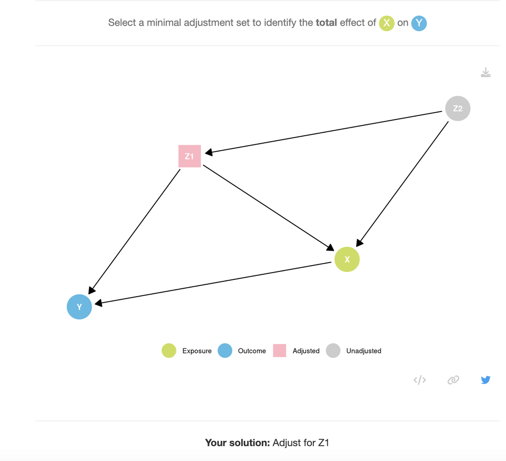

[figure not shown]

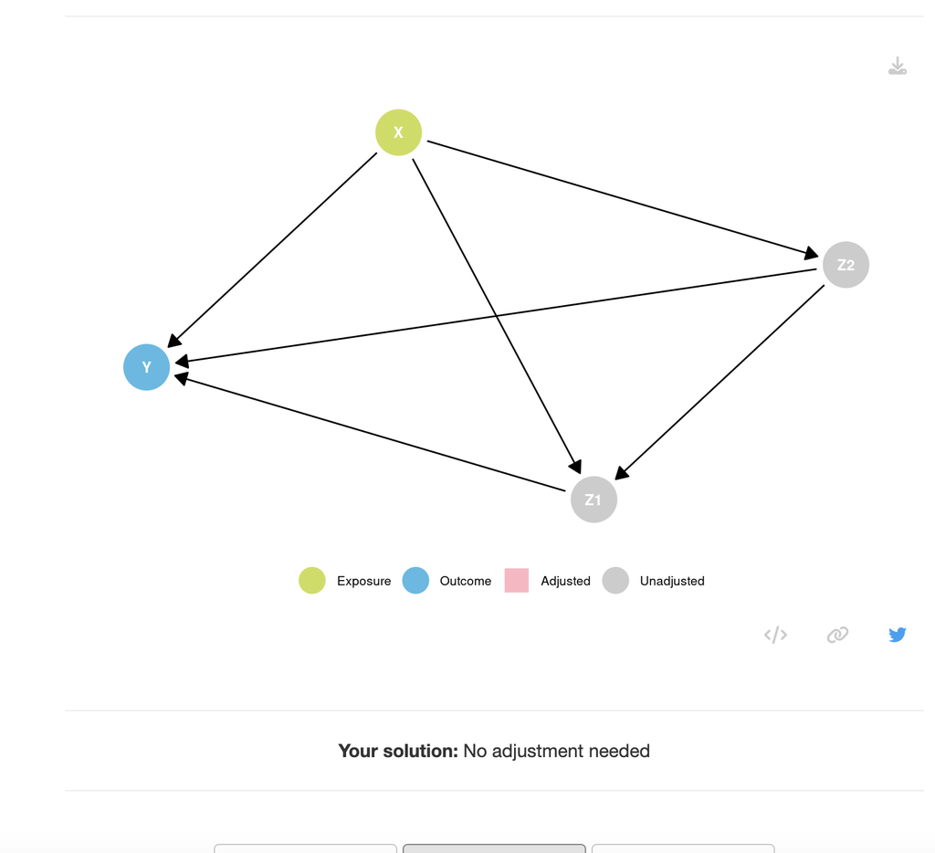

**6 nodes**

[figure not shown]

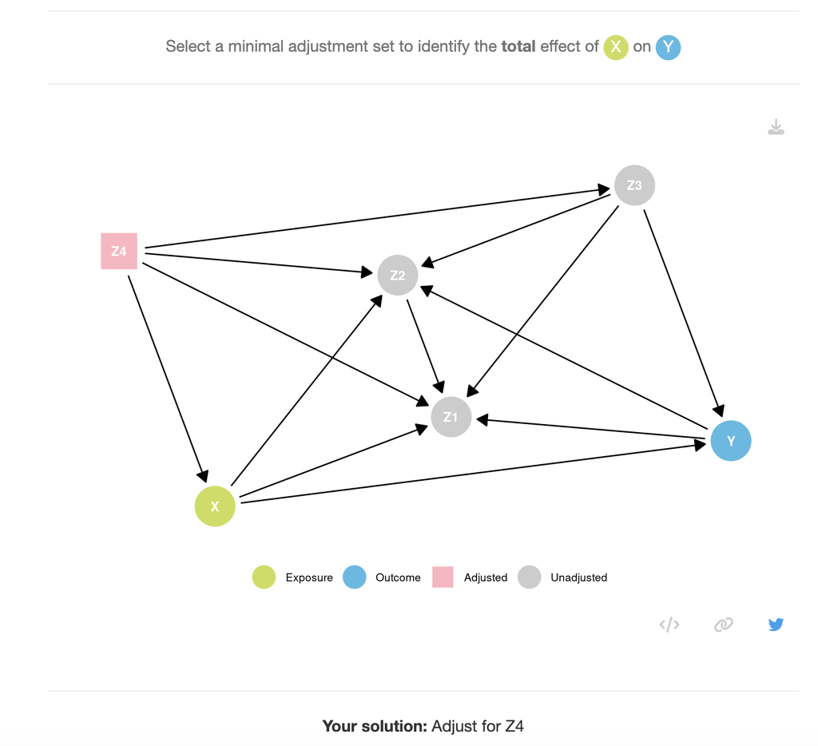

[figure not shown]

**8 nodes**

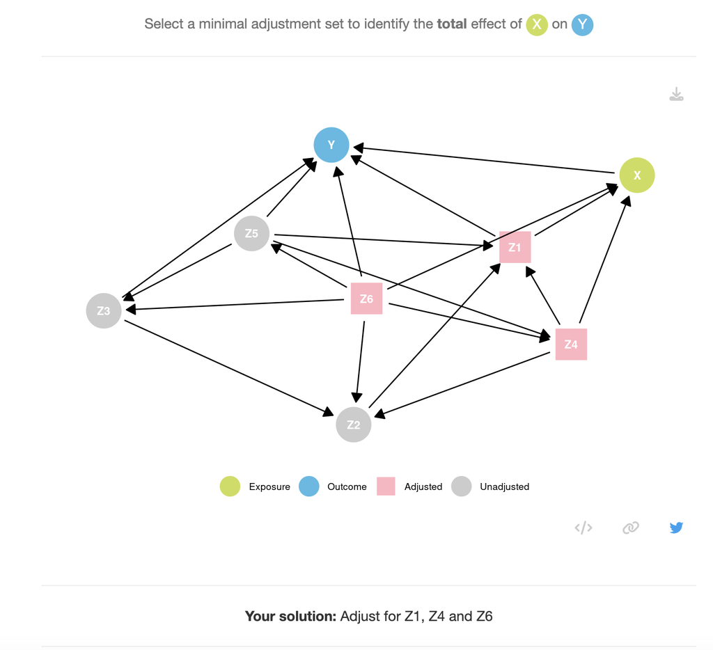

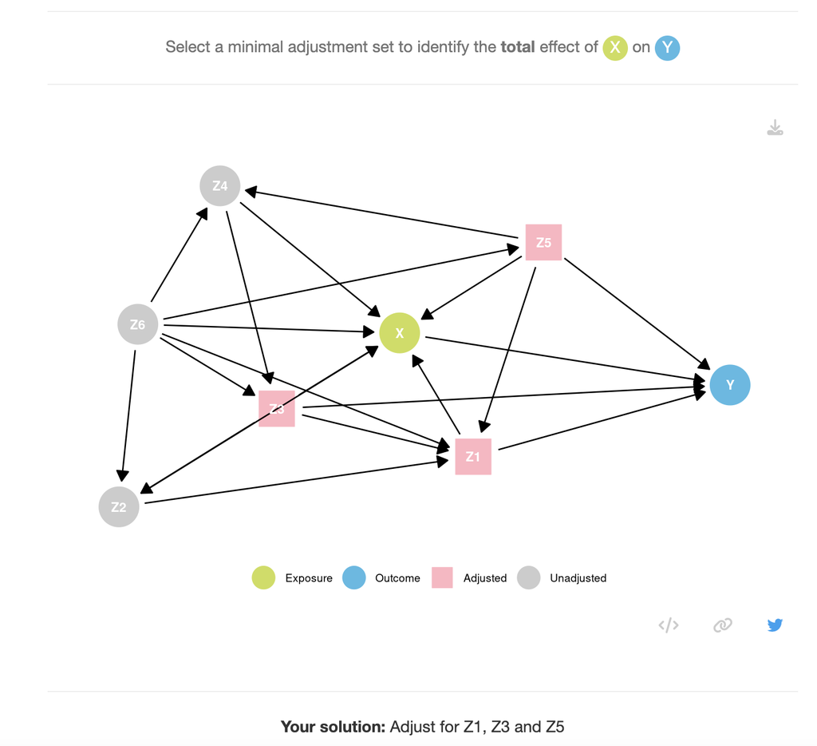

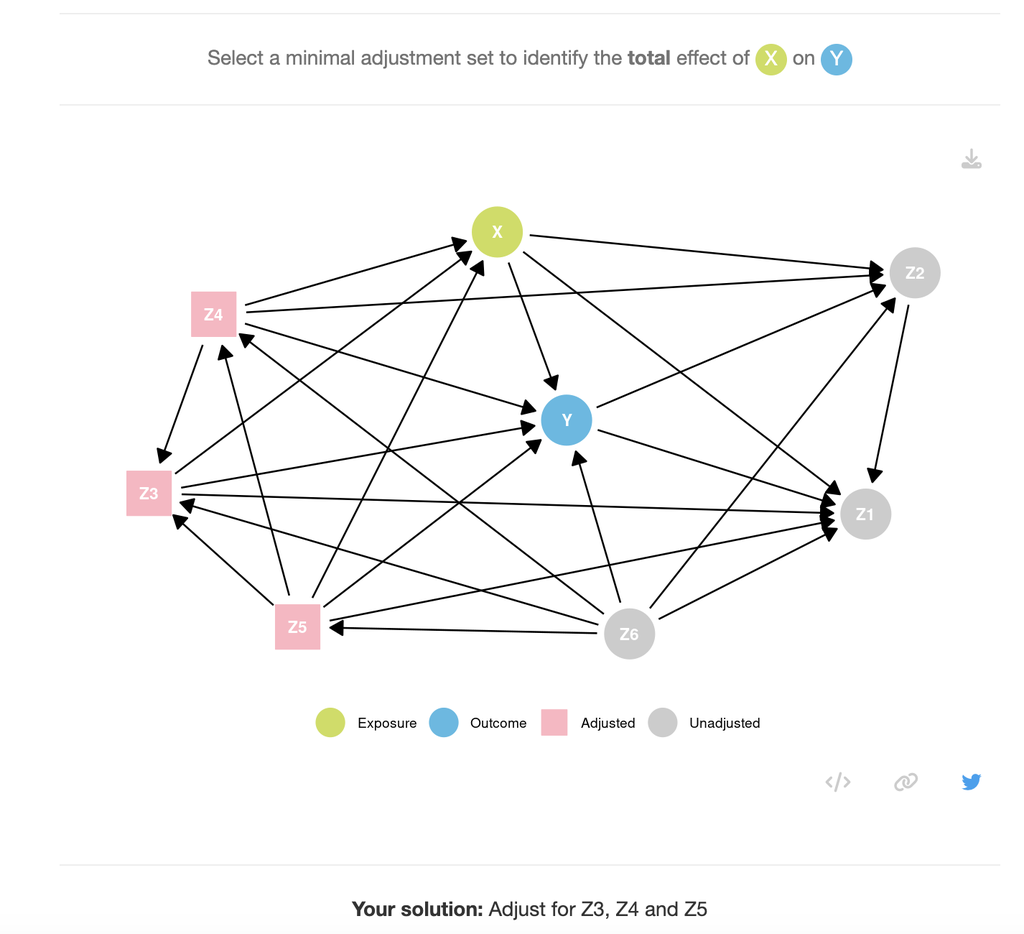

This got very difficult.